# G-BAGs example

Bora Jin

This document presents a simple demonstration of how to use some core functions in the package `bags`.

We start with loading necessary packages:

```r
library(tidyverse)
theme_set(theme_bw())
library(bags)
library(scico)
```

## Data generation

Let’s generate random data from prior sampling of univariate Bayesian regression models based on G-BAGs with Gaussian errors using the function `rbag()`.

That is, we generate $y(t) = x(t)^T\beta + w(t) + \epsilon(t)$ assuming $\epsilon(t) \sim N(0, \tau^2)$ and that spatiotemporal random effects $w$ follow a G-BAG prior with a base covariance function
$$C(h,u) = \frac{\sigma^2}{(a|u|+1)}\exp\left(-\frac{c||h||}{(a|u|+1)^{\kappa/2}}\right)$$
where $h$ is a spatial lag and $u$ is a temporal lag between two locations $t$ and $t'$.

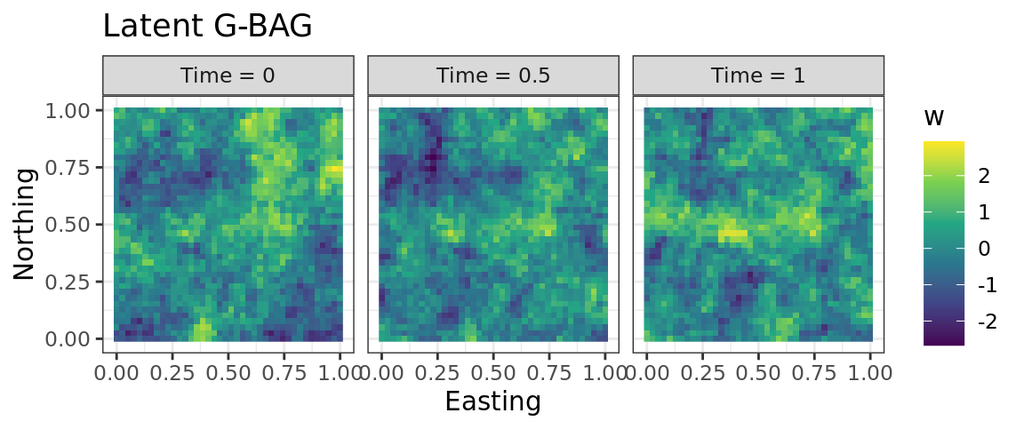

```r
# set seed
seed <- 20220720

# create coordinates on a grid
ngrid_e <- 40 # number of grid on the easting axis
ngrid_n <- 40 # number of grid on the northing axis
ngrid_t <- 3  # number of grid on the time axis

grid_e <- seq(0, 1, length = ngrid_e)
grid_n <- seq(0, 1, length = ngrid_n)
grid_t <- seq(0, 1, length = ngrid_t)
coords <- expand.grid(easting = grid_e, northing = grid_n, time = grid_t) %>%
  arrange(time, easting, northing)
n <- nrow(coords)

# set the number of partitions in each coordinate axis
n_easting <- 25
n_northing <- 1
n_time <- 3

# set the true direction
z_true <- rep("W", times = n_easting*n_northing*n_time)

# set parameters
a <- 1
c <- 7
kappa <- 0
sig_sq <- 1
tau_sq <- 0.1
beta <- c(2, -1)

# generate data
data <- rbag(coords = coords,
             n_partition = c(n_easting, n_northing, n_time),
             breaks_partition = list(breaks_easting = NULL,
                                     breaks_northing = NULL,
                                     breaks_time = NULL),
             z = z_true,
             params = list(tau_sq = tau_sq,
                           sig_sq = sig_sq,
                           a = a, c = c, kappa = kappa,
                           beta = beta),
             seed = seed)

# plot latent w
data %>%
  ggplot() +
  geom_raster(aes(easting, northing, fill = w)) +
  facet_grid(~ factor(time, label = paste("Time =", sort(unique(time))))) +
  scale_fill_viridis_c() +
  labs(x = "Easting", y = "Northing", title = "Latent G-BAG")
```

## Covariance

Following notations of the manuscript, we can compute $\tilde{C}_{z}$ using the function `Ctilde()`. $\tilde{C}_{z}$ is the G-BAG induced nonstationary covariance matrix of a reference set $S$ conditional on a DAG configuration $z$, i.e., $\tilde{p}(w_S \mid z) = N(0, \tilde{C}_z)$.

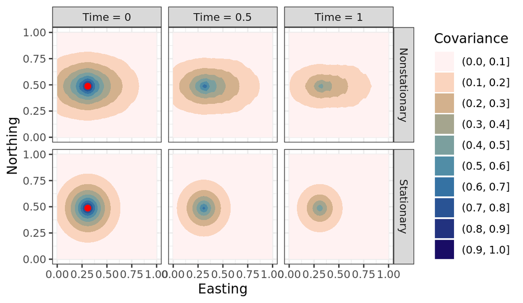

```r
# extract coordinate-relevant columns
coords_ptt <- data %>%
  select(-y, -w, -starts_with("X"))

# compute G-BAG derived nonstationary covariance matrix
nonstCov <- Ctilde(coords_ptt = coords_ptt,
                   z = as.matrix(z_true),
                   params = list(sig_sq = sig_sq, a = a, c = c, kappa = kappa))

# compute the base stationary covariance matrix
spatdist <- dist(coords_ptt[,c("easting", "northing")], method = "euclidean")
timedist <- dist(coords_ptt[,c("time")], method = "manhattan")
invaup1 <- 1/(a*as.matrix(timedist)+1)
stCov <- sig_sq*invaup1*exp(-c*as.matrix(spatdist)*(invaup1^(kappa/2)))

# plot the covariance with a randomly selected point
i_ref <- 500
coords_ptt %>%
  mutate(Nonstationary = nonstCov[i_ref,],
         Stationary = stCov[i_ref,]) %>%
  pivot_longer(cols = Nonstationary:Stationary,
               names_to = "cat",
               values_to = "cov") %>%
  ggplot() +
  geom_contour_filled(aes(easting, northing, z = cov)) +
  scale_fill_scico_d(palette = "lapaz", direction = -1) +
  geom_point(data = coords_ptt[i_ref,],
             aes(easting, northing), size = 2, col = "red") +
  facet_grid(cat ~ factor(time, label = paste("Time =", sort(unique(time))))) +
  labs(x = "Easting", y = "Northing", fill = "Covariance")
```

## Posterior sampling

Suppose we observe only 80% of the data.

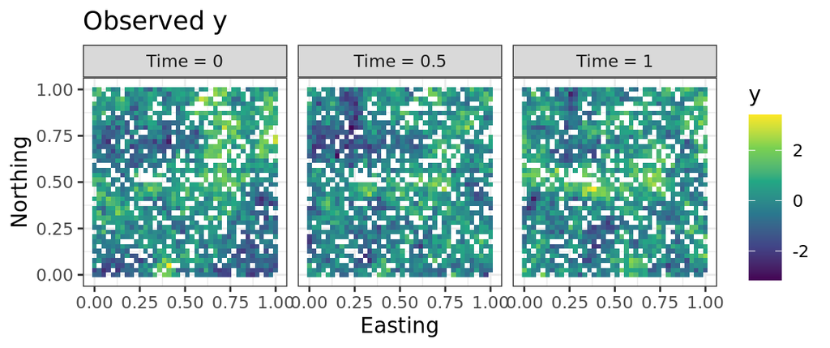

```r
# set seed
set.seed(seed)

# assign 80% of data to train data
coords_tr <- expand.grid(easting = grid_e, northing = grid_n) %>%
  slice_sample(prop = 0.8) %>%
  bind_cols(as.list(setNames(grid_t[1:ngrid_t], paste0("time_", 1:ngrid_t)))) %>%
  pivot_longer(starts_with("time_"),
               values_to = "time") %>%
  select(-name) %>%
  arrange(time, easting, northing)
data_tr <- left_join(coords_tr, data, by = c("easting", "northing", "time"))
data_tt <- anti_join(data, data_tr, by = c("easting", "northing", "time"))
coords_tt <- data_tt[,c("easting", "northing", "time")]

y_tr <- data_tr$y
X_tr <- data_tr %>% select(starts_with("X"))
X_tt <- data_tt %>% select(starts_with("X"))

# plot observed y
data_tr %>%
  ggplot() +
  geom_raster(aes(easting, northing, fill = y)) +
  facet_grid(~ factor(time, label = paste("Time =", sort(unique(time))))) +
  scale_fill_viridis_c() +
  labs(x = "Easting", y = "Northing", title = "Observed y")
```

With the train data above, we run posterior sampling of the Bayesian regression and make predictions at the test data using the function `bag()`.

Users can specify hyperparameters in prior distributions. For temporal and spatial decay, for instance, we assign `la` $= 0$, `ua` $= 2$, `lc` $= 6$, and `uc` $= 8$, assuming $a \sim Unif(0, 2)$ and $c \sim Unif(6, 8)$.

```r
# set directions
directions <- c("W", "NW", "N")

# set mcmc
mcmc <- list(save = 1000, burn = 1000, thin = 2)

# run bag sampler
out <- bag(y = y_tr,
           X = as.matrix(X_tr),
           coords = as.matrix(coords_tr),
           X_pred = as.matrix(X_tt),
           coords_pred = as.matrix(coords_tt),
           n_partition = c(n_easting, n_northing, n_time),
           breaks_partition = list(breaks_easting = NULL,
                                   breaks_northing = NULL,
                                   breaks_time = NULL),
           directions = directions,
           init = list(tau_sq = NULL,
                       sig_sq = NULL,
                       w = NULL,
                       z = NULL,
                       psi = NULL,
                       Sn = NULL),
           hyper = list(at = NULL, bt = NULL,
                        as = NULL, bs = NULL,
                        la = 0, ua = 2,
                        lc = 6, uc = 8,
                        mu0 = NULL, invV0 = NULL),
           mcmc = mcmc,
           n_threads = 10,
           seed = seed,
           verbose = FALSE,
           save_data = TRUE,
           save_est = TRUE,
           debug = list(psi_fixed = FALSE, z_fixed = FALSE))
```

## Inferences

After running the function `bag()`, we can analyze posterior samples of the parameters, recover the latent process $w$, and visualize prediction of $y(t)$ at missing locations.

```r
# tau_sq = 0.1
mean(out$tau_sq_save) %>% round(3)
## 0.102

# beta = c(2, -1)
rowMeans(out$beta_save) %>% round(3)
## 2.021, -1.121

# sig_sq = 1
mean(out$sig_sq_save) %>% round(3)
## 0.945

# psi = c(a, c, kappa) = c(1, 7, 0)
rowMeans(out$psi_save) %>% round(3)
## 0.970, 7.327, 0.339

# w
w_bag <- c(rowMeans(out$w_save), # estimated
           rowMeans(out$w_pred_save)) # predicted

# y
y_bag <- c(rowMeans(out$y_save), # estimated
           rowMeans(out$y_pred_save)) # predicted
```

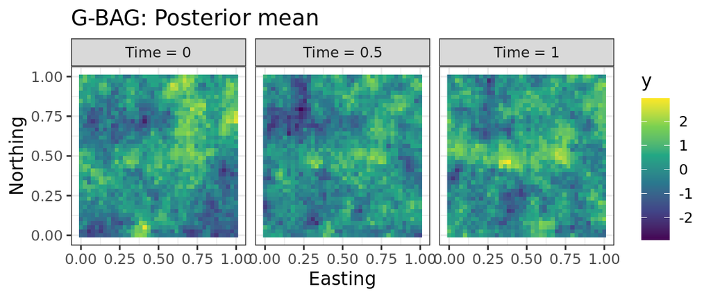

```r
# plot predicted space by G-BAG
bind_rows(coords_tr, coords_tt) %>%
  mutate(y = y_bag) %>%
  ggplot() +
  geom_raster(aes(easting, northing, fill = y)) +
  facet_grid( ~ factor(time, label = paste("Time =", sort(unique(time))))) +
  scale_fill_viridis_c() +
  labs(x = "Easting", y = "Northing", title = "G-BAG: Posterior mean")
```

Furthermore, we can examine inferred directions.

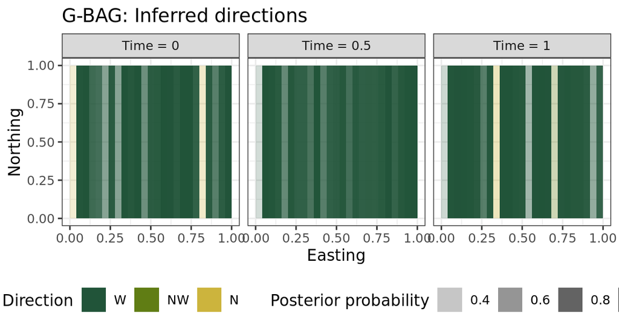

```r
# compute posterior probability of choosing each direction at each partition
dir_prop <- data.frame(
  W = rowMeans(out$z_save == "W"),
  NW = rowMeans(out$z_save == "NW"),
  N = rowMeans(out$z_save == "N")
)

# derive the highest posterior probability and associated direction
dir_hpp <- apply(dir_prop, 1, function(x) directions[which.max(x)])
val_hpp <- apply(dir_prop, 1, max)

# compute the center of each partition for regularly spaced partitions
easting_cut <- seq(0, 1, length = n_easting + 1)
northing_cut <- seq(0, 1, length = n_northing + 1)
easting_midval <- 0.5*easting_cut[1:n_easting] + 0.5*easting_cut[-1]
northing_midval <- 0.5*northing_cut[1:n_northing] + 0.5*northing_cut[-1]

# create a data frame that links derived directions and partition centers
bag_dir <- data.frame(partition = sort(unique(data_tr$partition)),
                      direction = factor(z_true, levels = directions),
                      dir_hpp = factor(dir_hpp, levels = directions),
                      val_hpp = val_hpp) %>%
  separate(partition, c("row", "col", "time_d"), sep = ",", convert = TRUE) %>%
  mutate(easting_center = easting_midval[col],
         northing_center = northing_midval[n_northing + 1 - row],
         time = grid_t[time_d])

# visualize inferred directions
bag_dir %>% ggplot() +
  geom_tile(aes(x = easting_center, y = northing_center,
                fill = dir_hpp, alpha = val_hpp)) +
  labs(x = "Easting", y = "Northing",
       alpha = "Posterior probability", fill = "Direction",
       title = "G-BAG: Inferred directions") +
  scale_alpha(range = c(0.2, 1)) +
  facet_wrap(~ factor(time, label = paste("Time =", sort(unique(time))))) +
  scale_fill_scico_d(palette = "bamako",
                     begin = 0.2, end = 0.8) +
  theme(legend.position = "bottom")
```

We conclude the true direction “W” is well recovered by G-BAG with properly high posterior probabilities. Partitions which miss the true direction tend to be less opaque, implying the associated uncertainty is higher.